# Why Factor Analysis Messes Up

David Gerard

2016-07-11

# Abstract

I explore why the factor analysis is messing up the variance estimates.

# Analysis

## Generate Data Under Assumed Model

Load in needed libraries. `vicar` contains the function `rotate_model` that will be useful.

```r
library(cate)
library(ggplot2)
library(vicar)
library(reshape2)
```

Generate data under the assumed model. Here, I generate the confounders $Z$ such that they have in expectation an AR-1(0.7) covariance structure with the covariate of interest in $X$.

```r
set.seed(710)
n <- 40
p <- 1000
k <- 2
q <- 5
ncontrol = 500

## Generate Covariates and Confounders
X <- cbind(rep(1, n), c(rep(1, n / 2), rep(0, n / 2)))
var_x2 <- var(X[, 2])
rho <- 0.7
Sig <- var_x2 * rho ^ abs(outer(1:(q + 1), 1:(q + 1), "-"))
SigZ <- Sig[2:nrow(Sig), 2:nrow(Sig)] - Sig[2:nrow(Sig), 1, drop = FALSE] %*%
    Sig[1, 2:nrow(Sig), drop = FALSE] / var_x2
eSigZ <- eigen(SigZ)
SigZhalf <- eSigZ$vectors %*% diag(sqrt(eSigZ$values)) %*% t(eSigZ$vectors)
muZ <- Sig[2:nrow(Sig), 1, drop = FALSE] %*% t(X[, 2]) / var_x2
Z <- matrix(rnorm(q * n), nrow = n) %*% SigZhalf + t(muZ)
cov(cbind(X, Z))
```

```
##      [,1]    [,2]    [,3]    [,4]    [,5]    [,6]    [,7]
## [1,]    0 0.00000 0.00000 0.00000 0.00000 0.00000 0.00000
## [2,]    0 0.25641 0.17844 0.07960 0.07695 0.08056 0.05765
## [3,]    0 0.17844 0.22360 0.11754 0.07066 0.07255 0.07440
## [4,]    0 0.07960 0.11754 0.19625 0.10206 0.10355 0.09458
## [5,]    0 0.07695 0.07066 0.10206 0.15838 0.12337 0.09160
## [6,]    0 0.08056 0.07255 0.10355 0.12337 0.18645 0.15660
## [7,]    0 0.05765 0.07440 0.09458 0.09160 0.15660 0.29919
```

```r
## Generate Variances
sig_diag <- rchisq(p, df = 4) / 4
E <- matrix(rnorm(n * p), nrow = n) %*% diag(sqrt(sig_diag))

## Generate Coefficients and confounders
beta_mult <- 1
alpha_mult <- 1
beta <- matrix(rnorm(k * p), nrow = k) * beta_mult
beta[2, 1:750] <- 0
ctl <- rep(FALSE, length = p)
ctl[1:ncontrol] <- TRUE
alpha <- matrix(rnorm(q * p), nrow = q) * alpha_mult

## Now the full data
Y <- X %*% beta + Z %*% alpha + E
```

## Are variances accurately estimated with q correct?

The quasi-mle variance estimates are biased a little small. But the PCA variance estimates look unbiased. The adjusted variance estimates from using `vicar` look very inflated.

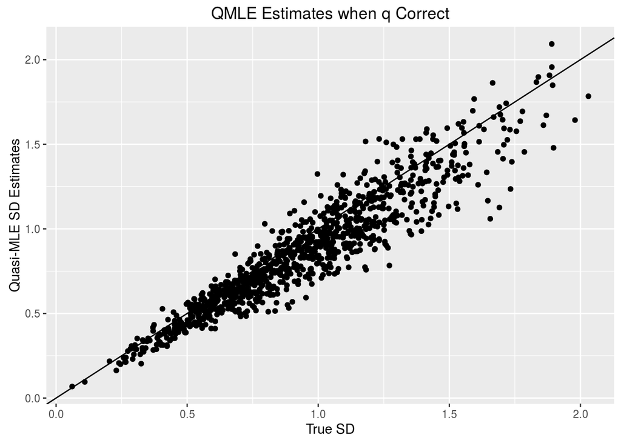

```r
rout <- vicar:::rotate_model(Y = Y, X = X, k = q, cov_of_interest = 2, do_factor = FALSE)
Y3 <- rout$Y3

qml_est <- cate::fa.em(Y = Y3, r = q)
pca_est <- vicar::pca_naive(Y = Y3, r = q)
qplot(sqrt(sig_diag), sqrt(qml_est$Sigma)) +
    geom_abline(intercept = 0, slope = 1) +
    xlab("True SD") +
    ylab("Quasi-MLE SD Estimates") +
    ggtitle("QMLE Estimates when q Correct")
```

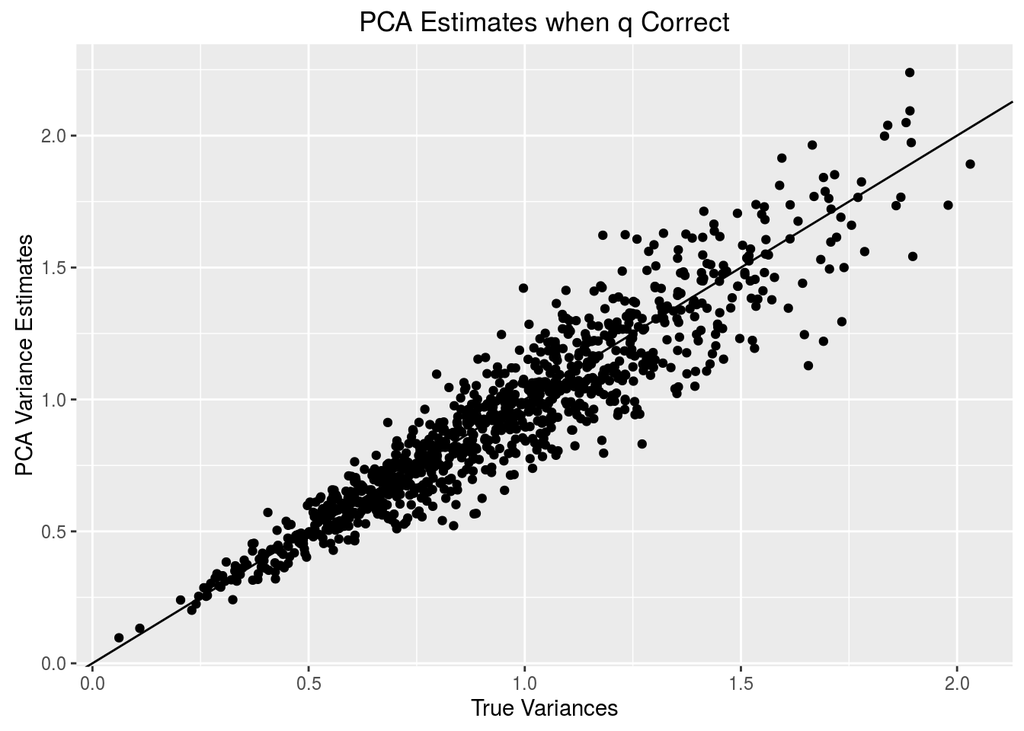

```r
qplot(sqrt(sig_diag), sqrt(pca_est$sig_diag)) +
    geom_abline(intercept = 0, slope = 1) +
    xlab("True Variances") +
    ylab("PCA Variance Estimates") +
    ggtitle("PCA Estimates when q Correct")
```

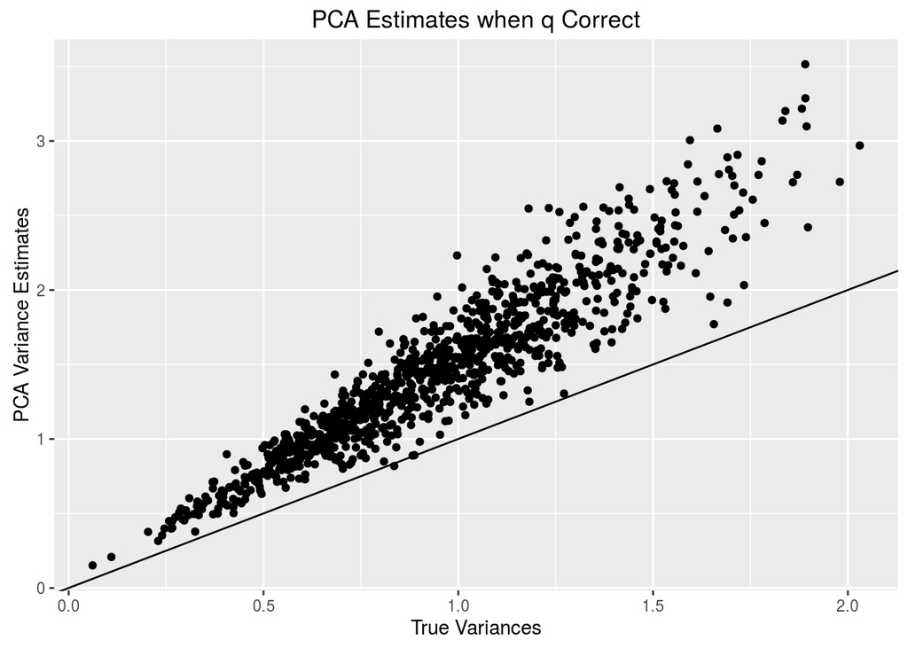

```r
## Variance Estimates are very inflated
vout <- vicar::vruv4(Y = Y, X = X, ctl = ctl, k = q, limmashrink = FALSE)
qplot(sqrt(sig_diag), sqrt(vout$sigma2_adjusted)) +
    geom_abline(intercept = 0, slope = 1) +
    xlab("True Variances") +
    ylab("PCA Variance Estimates") +
    ggtitle("PCA Estimates when q Correct")
```

```r
vout$multiplier
```

```
## [1] 2.464
```

```r
true_pi <- mean(beta[2, ] == 0)
```

The estimated multiplier is very large, being 2.4643.

Let’s look at the `ashr` results. The true $\pi_0$ is 0.75.

```r
ash1 <- ashr::ash(betahat = vout$betahat, sebetahat = vout$sebetahat_ols)
ash2 <- ashr::ash(betahat = vout$betahat, sebetahat = vout$sebetahat)
```

Using the RUV4 variance estimates, we get a $\pi_0$ estimate of 0.6678. Using variance inflation we get a $\pi_0$ estimate of 0.941.

The asymptotic variance results from CATE look really bad.

```r
## Cate Variance Estimates
cate_nc <- cate::cate(~Treatment, Y = Y,
                      X.data = data.frame(Treatment = X[, 2]),
                      r = q, adj.method = "nc", nc = ctl, calibrate = FALSE)
betahat_cate   <- c(cate_nc$beta)
sebetahat_cate <- c(sqrt(cate_nc$beta.cov.row * cate_nc$beta.cov.col) /
                    sqrt(nrow(X)))
ash3 <- ashr::ash(betahat = betahat_cate, sebetahat = sebetahat_cate)
ashr::get_pi0(ash3)
```

```
## [1] 0.5926
```

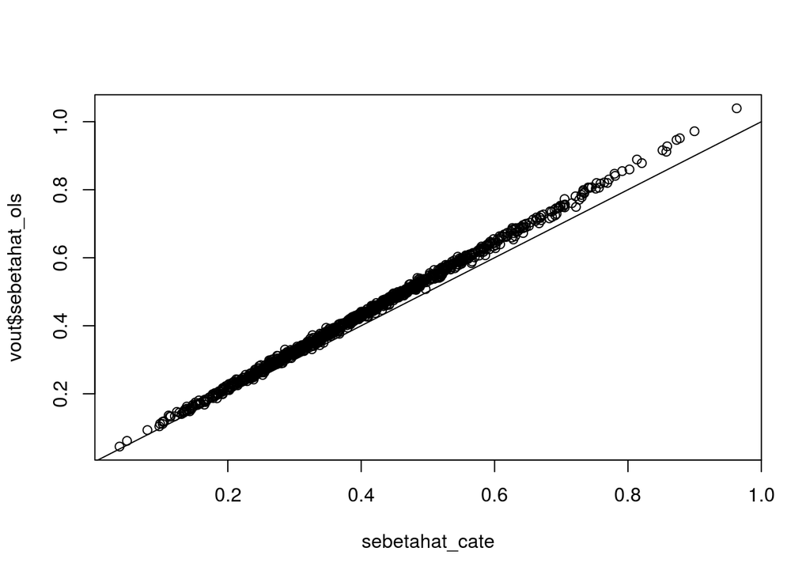

```r
plot(sebetahat_cate, vout$sebetahat_ols)
abline(0, 1)
```

What about the `succotashr` estimates of variance inflation?

```r
## succout <- succotashr::succotash(Y = Y, X = X, k = q, optmethod = "em")
## succout$scale_val
## succout$pi0
## plot(succout$betahat, ash2$PosteriorMean)
## abline(0, 1)
## ashr::get_pi0(vicar::ash_ruv4(Y = Y, X = X, ctl = ctl, k = q, limmashrink = FALSE))
```

## Ideal scenario with Z known.

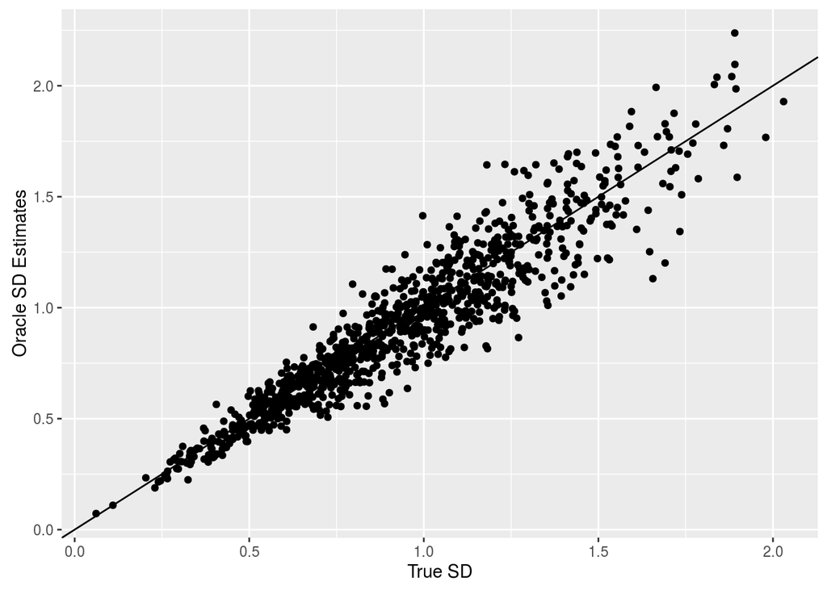

```r
XZ <- cbind(X, Z)

lmout <- limma::lmFit(object = t(Y), design = XZ)
betahat_lm <- lmout$coefficients[, 2]
sebetahat_lm <- lmout$sigma * lmout$stdev.unscaled[, 2]

qplot(sqrt(sig_diag), lmout$sigma) +
    geom_abline(intercept = 0, slope = 1) +
    xlab("True SD") +
    ylab("Oracle SD Estimates")
```

```r
ash4 <- ashr::ash(betahat = betahat_lm, sebetahat = sebetahat_lm)
```

Under the ideal scenario, the ashr estimate of $\pi_0$ is pretty good: 0.7212

Let’s look at the differences

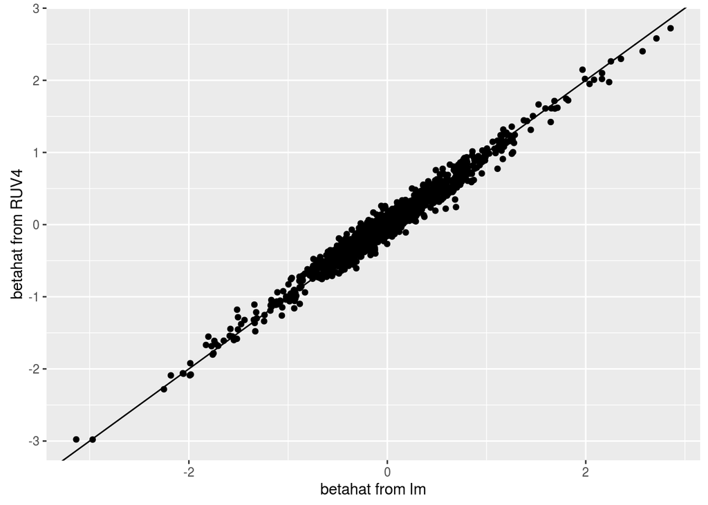

```r
qplot(betahat_lm, vout$betahat) +
    geom_abline(slope = 1, intercept = 0) +
    xlab("betahat from lm") +
    ylab("betahat from RUV4")
```

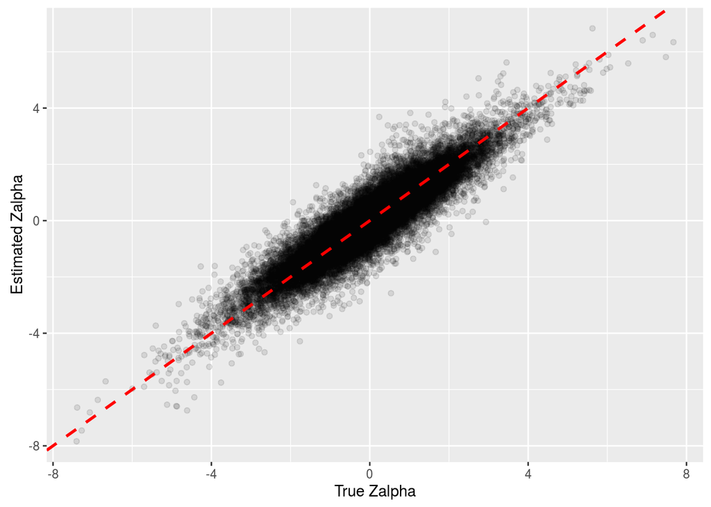

```r
true_za <- Z %*% alpha
est_za <- vout$Zhat %*% t(vout$alphahat)
ols_za <- Z %*% t(lmout$coefficients[, -c(1, 2)])

qplot(c(true_za), c(est_za), alpha = I(1/10)) +
    geom_abline(intercept = 0, slope = 1, color = 2, lty = 2, lwd = 1) +
    xlab("True Zalpha") +
    ylab("Estimated Zalpha")
```

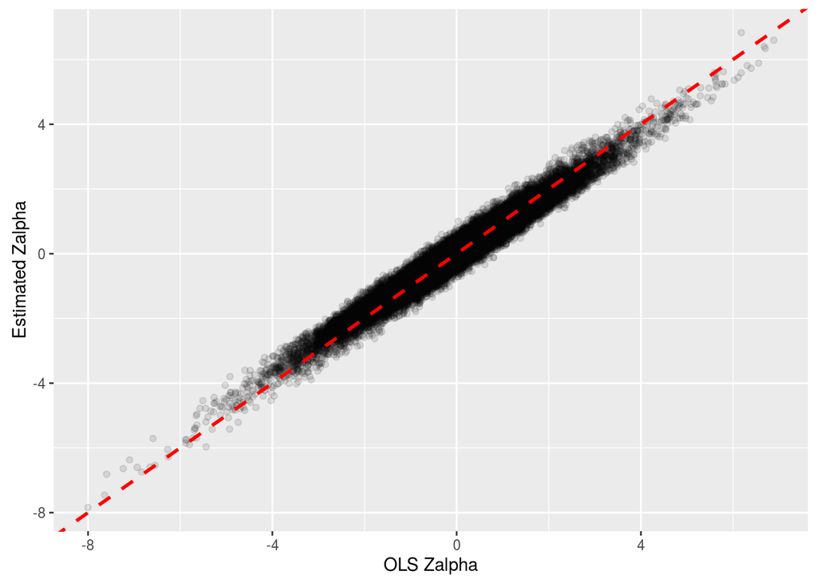

```r
qplot(c(ols_za), c(est_za), alpha = I(1/10)) +
    geom_abline(intercept = 0, slope = 1, color = 2, lty = 2, lwd = 1) +
    xlab("OLS Zalpha") +
    ylab("Estimated Zalpha")
```

```r
(mean((beta[, 2] - vout$betahat) ^ 2) + mean(sig_diag) + mean((true_za - est_za) ^ 2)) / mean(sig_diag)
```

```
## [1] 2.235
```

## Bad estimates of q

In the following plot, RUV4 is RUV4 + ash, vRUV4 is variance inflation in RUV4 + ash, vRUV4_limma is the same as the previous with all of the bells and whistles (limma shrunk variances, t-likelihood), and Cate is Cate + ash.

```r
qseq <- 1:(n - ncol(X) - 1)

num_sv <- sva::num.sv(dat = t(Y), mod = X)
cate_num_sv <- cate::est.confounder.num(~Treatment, Y = Y,
                                        X.data = data.frame(Treatment = X[, 2]),
                                        bcv.plot = FALSE)

results_mat <- matrix(NA, nrow = length(qseq), ncol = 5)
colnames(results_mat) <- c("Multiplier", "RUV4", "vRUV4", "vRUV4_limma", "Cate")
for (bad_q in qseq) {
    rout <- vicar:::rotate_model(Y = Y, X = X, k = bad_q, cov_of_interest = 2, do_factor = FALSE)
    Y3 <- rout$Y3

    vout <- vicar::vruv4(Y = Y, X = X, ctl = ctl, k = bad_q, limmashrink = FALSE)

    ash_out_limma <- vicar::ash_ruv4(Y = Y, X = X, ctl = ctl, k = bad_q, limmashrink = TRUE)
    ash1 <- ashr::ash(betahat = vout$betahat, sebetahat = vout$sebetahat_ols,
                      df = n - ncol(X) - bad_q)
    ash2 <- ashr::ash(betahat = vout$betahat, sebetahat = vout$sebetahat,
                      df = n - ncol(X) - bad_q)

    cate_nc <- cate::cate(~Treatment, Y = Y,
                          X.data = data.frame(Treatment = X[, 2]),
                          r = bad_q, adj.method = "nc", nc = ctl, calibrate = FALSE)
    betahat_cate   <- c(cate_nc$beta)
    sebetahat_cate <- c(sqrt(cate_nc$beta.cov.row * cate_nc$beta.cov.col) /
                        sqrt(nrow(X)))
    ash3 <- ashr::ash(betahat = betahat_cate, sebetahat = sebetahat_cate,
                      df = n - ncol(X) - bad_q)

    results_mat[bad_q, 1] <- vout$multiplier
    results_mat[bad_q, 2] <- ashr::get_pi0(ash1)
    results_mat[bad_q, 3] <- ashr::get_pi0(ash2)
    results_mat[bad_q, 4] <- ashr::get_pi0(ash_out_limma)
    results_mat[bad_q, 5] <- ashr::get_pi0(ash3)
}
```

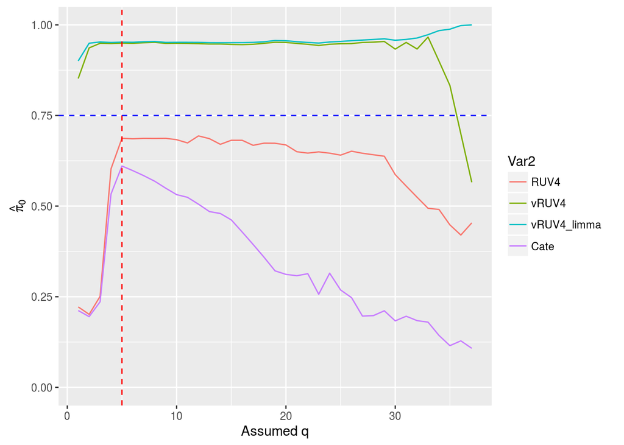

```r
longdat <- melt(results_mat[, -1], id.vars = NULL)
ggplot(data = longdat, mapping = aes(x = Var1, y = value, color = Var2)) +
    geom_line() + xlab("Assumed q") + ylab(expression(hat(pi)[0])) +
    geom_vline(xintercept = num_sv, col = 2, lty = 2) +
    geom_hline(yintercept = true_pi, col = 4, lty = 2) +
    ylim(0, 1)
```

The vertical line above is the estimated number of hidden confounders by `sva::num.sv`, which is 5. Using bi-crossvalidation, CATE estimates the number of hidden confounders to be 5.